# Proyecto_RFCancer

Carmen Sanchez Zapata

# 1 **INTRODUCCIÓN**

En este proyecto vamos a estudiar los factores de riesgo que pueden contribuir a la aparición de cancer y qué tipos. Empezaremos importando el fichero csv para ver la naturaleza de los datos de partida a las modificaciones de preprocesamiento que tenemos que hacer. Posteriormente, se seguirá estudiando la naturaleza de los datos mediante el uso de filtros para entender el comportamiento.

# 2 **RESUMEN**

Este proyecto presenta un análisis integral de los factores de riesgo asociados a cinco tipos de cáncer (mama, pulmón, próstata, piel y colon) y la clasificación del nivel de riesgo del paciente utilizando un conjunto de datos simulado de 2000 registros clínicos con 21 atributos a estudiar. El flujo metodológico incluye un preprocesamiento riguroso con normalización Min-Max y codificación dummy. En la fase exploratoria, se aplican filtros lógicos basados en hipótesis clínicas y agrupamiento no supervisado mediante K-Means y Análisis de Componentes Principales (PCA). Finalmente, se entrenan y comparan modelos supervisados de Random Forest, KNN y Árboles de Decisión. Para resolver el severo desbalanceo de la variable de riesgo, se integra la técnica de sobremuestreo SMOTE, lo que permite corregir el sesgo del modelo y dotarlo de una sensibilidad real para la detección de pacientes en estado crítico.

**SESION 1**

```r
data <- read.csv("cancer-risk-factors.csv")
head(data)
```

```
##   Patient_ID Cancer_Type Age Gender Smoking Alcohol_Use Obesity Family_History
## 1     LU0000      Breast  68      0       7           2       8              0
## 2     LU0001    Prostate  74      1       8           9       8              0
## 3     LU0002        Skin  55      1       7          10       7              0
## 4     LU0003       Colon  61      0       6           2       2              0
## 5     LU0004        Lung  67      1      10           7       4              0
## 6     LU0005        Lung  77      1      10           8       3              0
##   Diet_Red_Meat Diet_Salted_Processed Fruit_Veg_Intake Physical_Activity
## 1             5                     3                7                 4
## 2             0                     3                7                 1
## 3             3                     3                4                 1
## 4             6                     2                4                 6
## 5             6                     3               10                 9
## 6             6                     0                6                 2
##   Air_Pollution Occupational_Hazards BRCA_Mutation H_Pylori_Infection
## 1             6                    3             1                  0
## 2             3                    3             0                  0
## 3             8                   10             0                  0
## 4             4                    8             0                  0
## 5            10                    9             0                  0
## 6            10                    7             0                  0
##   Calcium_Intake Overall_Risk_Score  BMI Physical_Activity_Level Risk_Level
## 1              0          0.3986961 28.0                       5     Medium
## 2              5          0.4242990 25.4                       9     Medium
## 3              6          0.6050822 28.6                       2     Medium
## 4              8          0.3184487 32.1                       7        Low
## 5              5          0.5243584 25.1                       2     Medium
## 6              0          0.4986680 25.1                       1     Medium
```

```r
str(data)
```

```
## 'data.frame':    2000 obs. of  21 variables:
##  $ Patient_ID             : chr  "LU0000" "LU0001" "LU0002" "LU0003" ...
##  $ Cancer_Type            : chr  "Breast" "Prostate" "Skin" "Colon" ...
##  $ Age                    : int  68 74 55 61 67 77 59 74 71 55 ...
##  $ Gender                 : int  0 1 1 0 1 1 0 1 1 1 ...
##  $ Smoking                : int  7 8 7 6 10 10 10 8 9 7 ...
##  $ Alcohol_Use            : int  2 9 10 2 7 8 10 6 0 1 ...
##  $ Obesity                : int  8 8 7 2 4 3 0 2 3 2 ...
##  $ Family_History         : int  0 0 0 0 0 0 0 1 0 0 ...
##  $ Diet_Red_Meat          : int  5 0 3 6 6 6 9 3 10 0 ...
##  $ Diet_Salted_Processed  : int  3 3 3 2 3 0 4 3 4 4 ...
##  $ Fruit_Veg_Intake       : int  7 7 4 4 10 6 0 2 6 2 ...
##  $ Physical_Activity      : int  4 1 1 6 9 2 1 8 10 5 ...
##  $ Air_Pollution          : int  6 3 8 4 10 10 10 8 8 9 ...
##  $ Occupational_Hazards   : int  3 3 10 8 9 7 9 7 3 9 ...
##  $ BRCA_Mutation          : int  1 0 0 0 0 0 0 0 0 0 ...
##  $ H_Pylori_Infection     : int  0 0 0 0 0 0 0 0 0 0 ...
##  $ Calcium_Intake         : int  0 5 6 8 5 0 5 1 5 5 ...
##  $ Overall_Risk_Score     : num  0.399 0.424 0.605 0.318 0.524 ...
##  $ BMI                    : num  28 25.4 28.6 32.1 25.1 25.1 32.3 29.1 24.1 28.2 ...
##  $ Physical_Activity_Level: int  5 9 2 7 2 1 2 9 5 1 ...
##  $ Risk_Level             : chr  "Medium" "Medium" "Medium" "Low" ...
```

```r
ls <- unique(data$Cancer_Type)
print("Tipos de cancer a estudiar")
```

```
## [1] "Tipos de cancer a estudiar"
```

```r
ls
```

```
## [1] "Breast"   "Prostate" "Skin"     "Colon"    "Lung"
```

En los datos importados, vemos 21 variables con 2000 casos clínicos de pacientes.Dentro de los cancer a estudiar, nos centraremos en los cancer de mama, próstata, piel, colon y pulmón. Encontramos también la medida en la que afectan los factores genéticos y los estilos de vida. Podríamos dividir las variables en personales, alimentación y estilo de vida.

Como **factores personales**, contemplamos las variables de edad (Age), género (Gender), índice de masa corporal (BMI) e historia familiar (Family_History)

Como **factores alimentarios**, vemos la obesidad (Obesity), la dieta en carne roja (Diet_red_Meat), en procesados (Diet_Salted_Precossed), la alimentación a base de fruta y verduras (Fruit_Veg_Intake) y la ingesta de calcio (Calcium_Intake)

Como **factores de estilo de vida**, vemos si el paciente es fumador (Smoking), bebe (Alcohol_Use), la actividad física (Physical_Activity), el gasto metabólico total (Physical_Activity_Level), la polución del aire (Air_pollution), los riesgos laborales del paciente (Occupational_Hazards), la mutación del gen BRCA (BRCA_Mutation), relacionado con el cancer de mama y la infección de Helicobacter Pilori (H_Pylori_Infection), enzima del estómago que puede estar íntimammente relacionada con el cancer de colon

Encontramos también información adicional sobre el csv a tener en cuenta:

- Dentro del Risk_Level, encontramos ‘Low’, ‘Medium’ y ‘High’. Determinaremos ‘Low’ cuando el ‘Overall_Risk_Score’ sea inferior a 0.33; ‘Medium’ cuando sea mayor o igual de 0.33 y menor de 0.66 y ‘High’ cuando el valor mayor o igual a 0.66
- En Gender, se expresa en forma de 0 cuando es femenino y 1 cuando es masculino.

# 3 **PREPRPOCESAMIENTO**

Comenzaremos transformando las variables numéricas a valores de rango [0,1]

```r
summary(data)
```

```
##   Patient_ID        Cancer_Type             Age            Gender
##  Length:2000        Length:2000        Min.   :25.00   Min.   :0.000
##  Class :character   Class :character   1st Qu.:56.00   1st Qu.:0.000
##  Mode  :character   Mode  :character   Median :64.00   Median :0.000
##                                        Mean   :63.25   Mean   :0.489
##                                        3rd Qu.:70.00   3rd Qu.:1.000
##                                        Max.   :90.00   Max.   :1.000
##     Smoking        Alcohol_Use        Obesity       Family_History
##  Min.   : 0.000   Min.   : 0.000   Min.   : 0.000   Min.   :0.0000
##  1st Qu.: 2.000   1st Qu.: 2.000   1st Qu.: 4.000   1st Qu.:0.0000
##  Median : 5.000   Median : 5.000   Median : 6.000   Median :0.0000
##  Mean   : 5.157   Mean   : 5.035   Mean   : 5.968   Mean   :0.1945
##  3rd Qu.: 8.000   3rd Qu.: 8.000   3rd Qu.: 9.000   3rd Qu.:0.0000
##  Max.   :10.000   Max.   :10.000   Max.   :10.000   Max.   :1.0000
##  Diet_Red_Meat    Diet_Salted_Processed Fruit_Veg_Intake Physical_Activity
##  Min.   : 0.000   Min.   : 0.000        Min.   : 0.000   Min.   : 0.000
##  1st Qu.: 3.000   1st Qu.: 2.000        1st Qu.: 3.000   1st Qu.: 1.000
##  Median : 5.000   Median : 4.000        Median : 5.000   Median : 4.000
##  Mean   : 5.189   Mean   : 4.564        Mean   : 4.928   Mean   : 4.015
##  3rd Qu.: 8.000   3rd Qu.: 7.000        3rd Qu.: 8.000   3rd Qu.: 6.000
##  Max.   :10.000   Max.   :10.000        Max.   :10.000   Max.   :10.000
##  Air_Pollution    Occupational_Hazards BRCA_Mutation    H_Pylori_Infection
##  Min.   : 0.000   Min.   : 0.000       Min.   :0.0000   Min.   :0.0000
##  1st Qu.: 3.000   1st Qu.: 2.000       1st Qu.:0.0000   1st Qu.:0.0000
##  Median : 5.000   Median : 5.000       Median :0.0000   Median :0.0000
##  Mean   : 5.323   Mean   : 4.979       Mean   :0.0325   Mean   :0.1965
##  3rd Qu.: 8.000   3rd Qu.: 8.000       3rd Qu.:0.0000   3rd Qu.:0.0000
##  Max.   :10.000   Max.   :10.000       Max.   :1.0000   Max.   :1.0000
##  Calcium_Intake   Overall_Risk_Score      BMI        Physical_Activity_Level
##  Min.   : 0.000   Min.   :0.02928    Min.   :15.00   Min.   : 0.000
##  1st Qu.: 1.000   1st Qu.:0.36698    1st Qu.:23.50   1st Qu.: 2.000
##  Median : 4.000   Median :0.45540    Median :26.20   Median : 5.000
##  Mean   : 3.941   Mean   :0.45445    Mean   :26.18   Mean   : 4.939
##  3rd Qu.: 6.000   3rd Qu.:0.53978    3rd Qu.:28.70   3rd Qu.: 8.000
##  Max.   :10.000   Max.   :0.85216    Max.   :41.40   Max.   :10.000
##   Risk_Level
##  Length:2000
##  Class :character
##  Mode  :character
##
##
##
```

```r
colSums(is.na(data))
```

```
##              Patient_ID             Cancer_Type                     Age
##                       0                       0                       0
##                  Gender                 Smoking             Alcohol_Use
##                       0                       0                       0
##                 Obesity          Family_History           Diet_Red_Meat
##                       0                       0                       0
##   Diet_Salted_Processed        Fruit_Veg_Intake       Physical_Activity
##                       0                       0                       0
##           Air_Pollution    Occupational_Hazards           BRCA_Mutation
##                       0                       0                       0
##      H_Pylori_Infection          Calcium_Intake      Overall_Risk_Score
##                       0                       0                       0
##                     BMI Physical_Activity_Level              Risk_Level
##                       0                       0                       0
```

Esto demuestra que no tenemos datos faltantes

**SESIÓN 2**

Comenzamos normalizando nuestras variables

```r
min_max_norm <- function(x) {
  if (max(x, na.rm = TRUE) - min(x, na.rm = TRUE) == 0) return(x)
  return((x - min(x, na.rm = TRUE)) / (max(x, na.rm = TRUE) - min(x, na.rm = TRUE)))
}

data_num <- data %>%
  mutate(across(where(is.numeric), min_max_norm))

df <- dummy_cols(
  data_num,
  select_columns = "Cancer_Type",
  remove_first_dummy = FALSE,
  remove_selected_columns = TRUE
)


head(df)
```

```
##   Patient_ID       Age Gender Smoking Alcohol_Use Obesity Family_History
## 1     LU0000 0.6615385      0     0.7         0.2     0.8              0
## 2     LU0001 0.7538462      1     0.8         0.9     0.8              0
## 3     LU0002 0.4615385      1     0.7         1.0     0.7              0
## 4     LU0003 0.5538462      0     0.6         0.2     0.2              0
## 5     LU0004 0.6461538      1     1.0         0.7     0.4              0
## 6     LU0005 0.8000000      1     1.0         0.8     0.3              0
##   Diet_Red_Meat Diet_Salted_Processed Fruit_Veg_Intake Physical_Activity
## 1           0.5                   0.3              0.7               0.4
## 2           0.0                   0.3              0.7               0.1
## 3           0.3                   0.3              0.4               0.1
## 4           0.6                   0.2              0.4               0.6
## 5           0.6                   0.3              1.0               0.9
## 6           0.6                   0.0              0.6               0.2
##   Air_Pollution Occupational_Hazards BRCA_Mutation H_Pylori_Infection
```

[output cut: 27 more lines]

# 4 **FILTROS**

Haremos a continuación algunos estudios para tratar los datos más en profundidad. Primero es necesario saber con cuántos casos de cada cancer contamos

```r
vars <- c("Cancer_Type_Skin", "Cancer_Type_Breast", "Cancer_Type_Lung",
          "Cancer_Type_Prostate", "Cancer_Type_Colon")

sapply(df[vars], function(x) sum(x == 1, na.rm = TRUE))
```

```
##     Cancer_Type_Skin   Cancer_Type_Breast     Cancer_Type_Lung
##                  290                  460                  527
## Cancer_Type_Prostate    Cancer_Type_Colon
##                  305                  418
```

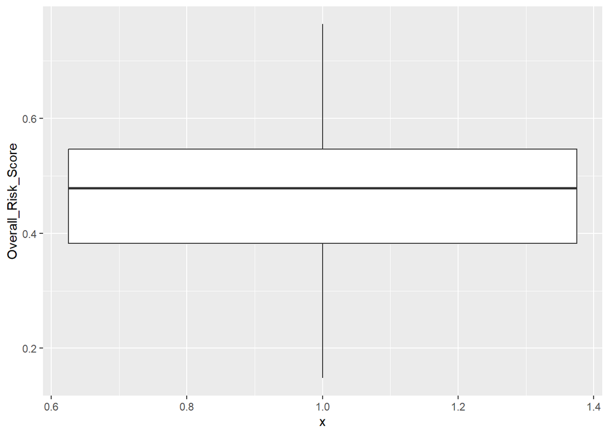

```r
#Filtramos los valores personales: edad mayor a 40 años, BMI mayor que la media y la historia familiar a 1
var <- data %>%
  filter(Age >= 40, BMI >= mean(BMI), Family_History == 1)
#Nos devuelve 208 casos de pacientes con cancer que cumplen estas condiciones. Supone poco más del 10% de nuestros datos. Veremos a continuación si estas condciones determinan un riesgo alto, bajo o medio de cancer


data %>%
  filter(Age >= 40, BMI >= mean(BMI), Family_History == 1)%>%
ggplot(aes(x=1,y=Overall_Risk_Score))+
  geom_boxplot()
```

Viendo en la media y los cuartiles de los datos personales, los riesgos de cancer son ‘Medium’. No sería concluyente pero podríamos desarrollar una hipótesis que los facotres personales generan un riesgo medio de cancer

Filtraremos ahora los facotres alimentarios:

```r
#Filtramos los valores alimentarios: la obesidad, la dieta en carne roja, la alimentación a base de procesados, la ingesta de frutas y de verduras y la ingesta de calcio mayor que la media. De esta manera, podemos ver si una alimantación excesiva puede afectar

alimentacion <- data_num %>%
  filter(Obesity >= mean(Obesity), Diet_Red_Meat >= mean (Diet_Red_Meat), Diet_Salted_Processed >= mean(Diet_Salted_Processed), Fruit_Veg_Intake >= mean(Fruit_Veg_Intake),
         Calcium_Intake >= mean(Calcium_Intake))

#Vamos a hacer también un estudio donde veremos la obesidad, la dieta en carne roja y procesados

alimentacion2 <- data_num %>%
  filter(Obesity >= mean(Obesity), Diet_Red_Meat >= mean (Diet_Red_Meat), Diet_Salted_Processed >= mean(Diet_Salted_Processed))

table(alimentacion$Cancer_Type)
```

```
##
##   Breast    Colon     Lung Prostate     Skin
##        5       24       11        6        7
```

```r
table(alimentacion2$Cancer_Type)
```

```
##
##   Breast    Colon     Lung Prostate     Skin
##       56      116       38       25       19
```

Para el filtro alimenticio de todos los componenetes, no encontramos más resultados que 53 (5+24+11+6+7). Vemos que, aunque por poca diferenica, destaca en el cancer de colon. Sin embargo, cuando reducimos la búsqueda a solo 3 componentes, encontramos 254 casos que supone el 12.7% de los casos. No encontramos relación clara con el cancer de colon pero es cierto que hay 116 casos en comparación con el primero que serían 53.

Con este filtro, podemos sospechar que los algortimos de aprendizaje supervisado tendrán más facilidad a la hora de la predicción si se consideran pocas variables.

```r
summary(alimentacion2$Overall_Risk_Score)
```

```
##    Min. 1st Qu.  Median    Mean 3rd Qu.    Max.
##  0.2585  0.5270  0.6341  0.6287  0.7387  1.0000
```

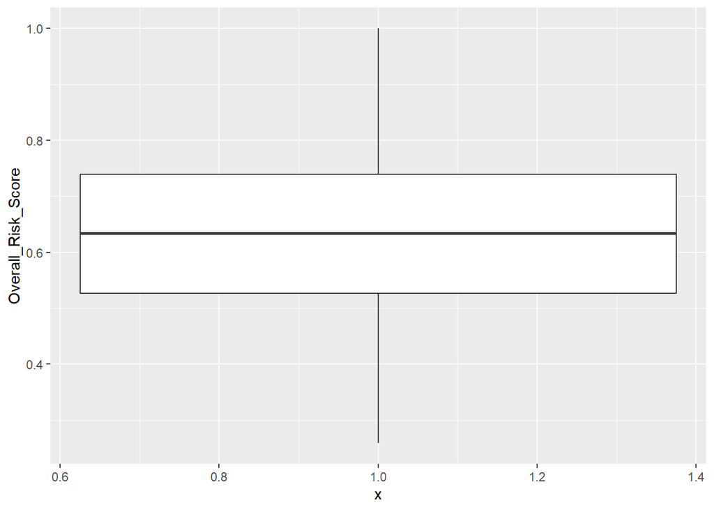

```r
alimentacion2 %>%
ggplot(aes(x=1,y=Overall_Risk_Score))+
  geom_boxplot()
```

Esta caja de bigotes si muestra los valores ligeramente desplazados (aunque mínimo) hacia un riesgo Medio - Alto. Buscaremos ahora relación entre el cancer de colon y la obesidad o la dieta en carne roja y procesados o la ingesta de calcio

```r
count(df %>%
  filter(Obesity > 0, Cancer_Type_Colon==1))
```

```
##     n
## 1 384
```

```r
count(df %>%
  filter(Diet_Red_Meat >= quantile(Diet_Red_Meat), Diet_Salted_Processed >= quantile(Diet_Salted_Processed), Cancer_Type_Colon==1))
```

```
##     n
## 1 271
```

```r
count(df %>%
  filter(Calcium_Intake >= mean(Calcium_Intake), Cancer_Type_Colon==1))
```

```
##     n
## 1 244
```

Respecto a los factores de estilo de vida, atenderemos distintas situaciones como la mutación del gen BRCA con el cancer de mama, el nivel de tabaco y la polución del aire con el cancer de pulmón, el nivel metabólico y el nivel de alcohol con el cancer de próstata, la actividad física, la obesidad y la infección de la Helicobacter Pilori con el cancer de colon, el tabaco y los riesgos laborales con el cancer de piel

```r
count(df %>%
  filter(BRCA_Mutation > 0, Cancer_Type_Breast==1))
```

```
##    n
## 1 37
```

```r
pulmon <- df %>%
  filter(Smoking >0, Air_Pollution >= 0, Cancer_Type_Lung==1)
count(pulmon)
```

```
##     n
## 1 527
```

```r
summary(pulmon$Overall_Risk_Score)
```

```
##    Min. 1st Qu.  Median    Mean 3rd Qu.    Max.
##  0.1383  0.4788  0.5725  0.5719  0.6715  1.0000
```

```r
count(df %>%
  filter(Physical_Activity_Level < mean(Physical_Activity_Level), Alcohol_Use >= mean(Alcohol_Use), Cancer_Type_Prostate==1))
```

```
##    n
## 1 79
```

```r
count(df %>%
  filter(Physical_Activity < quantile(Physical_Activity), Obesity > 0, H_Pylori_Infection ==1, Cancer_Type_Colon==1))
```

```
##    n
## 1 24
```

```r
count(df %>%
  filter(Smoking > 0, Occupational_Hazards >= 0.5, Cancer_Type_Skin==1))
```

```
##     n
## 1 230
```

Estos resultados no son muy determinantes excepto dos casos:

- En la relación entre el cancer de pulmón y el tabaco y la polución del aire encontramos los 527 casos existentes. Es cierto que los filtros son básicos ya que hemos considerado que si el paciente fuma (da igual la medida) y/o hay polución en al aire (ignoramos el nivel de polución), existe cancer de pulmón
- En la relación con el tabaco, los riesgos laborales y el cancer de piel, encontramos 230 resultados, considerando que contamos con 290 casos de este tipo de cancer, lo que supone un 79.31% de casos

**SESIÓN 3**

# 5 **APRENDIZAJE NO SUPERVISADO**

## 5.1 **Algortimo K-Means**

Vamos a llevar a cabo un clustering de tipo K-means

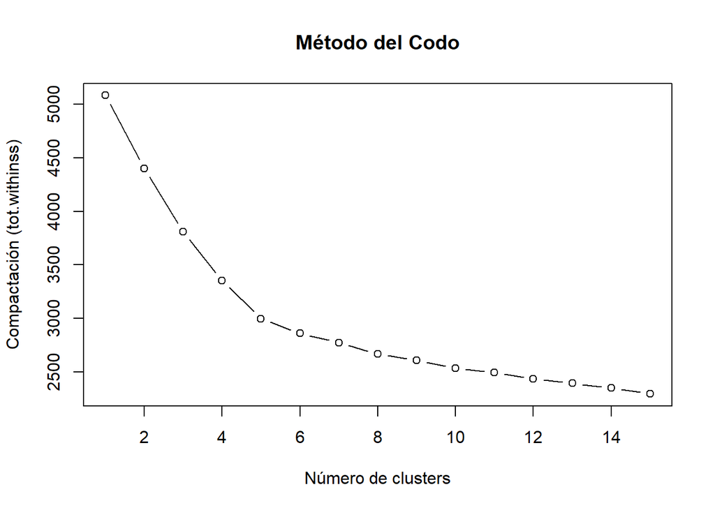

```r
df_num <- df[, sapply(df, is.numeric)]
vector_compactacion <- numeric(15)

for(i in 1:15){
  km_datos <- kmeans(df_num, centers = i, nstart = 20)
  vector_compactacion[i] <- km_datos$tot.withinss
}

# Grafica
par(mfrow=c(1,1))
plot(1:15, vector_compactacion, type = "b",
     xlab = "Número de clusters",
     ylab = "Compactación (tot.withinss)",
     main = "Método del Codo")
```

```r
km_datos<-kmeans(df_num,center=4,nstar=20) #segun el metodo del codo
cat('Breast')
```

```
## Breast
```

```r
print(table(km_datos$cluster, df$Cancer_Type_Breast))
```

```
##
##       0   1
##   1 418   0
##   2   0 460
##   3 595   0
##   4 527   0
```

```r
##################
cat('Lung')
```

```
## Lung
```

```r
print(table(km_datos$cluster, df$Cancer_Type_Lung))
```

```
##
##       0   1
##   1 418   0
##   2 460   0
##   3 595   0
##   4   0 527
```

```r
##################
cat('Prostate')
```

```
## Prostate
```

```r
print(table(km_datos$cluster, df$Cancer_Type_Prostate))
```

```
##
##       0   1
##   1 418   0
##   2 460   0
##   3 290 305
##   4 527   0
```

```r
##################
cat('Skin')
```

```
## Skin
```

```r
print(table(km_datos$cluster, df$Cancer_Type_Skin))
```

```
##
##       0   1
##   1 418   0
##   2 460   0
##   3 305 290
##   4 527   0
```

```r
##################
cat('Colon')
```

```
## Colon
```

```r
print(table(km_datos$cluster, df$Cancer_Type_Colon))
```

```
##
##       0   1
##   1   0 418
##   2 460   0
##   3 595   0
##   4 527   0
```

```r
#############

km_datos2<-kmeans(df_num,center=5,nstar=20) #numero de cancer

cat('Breast')
```

```
## Breast
```

```r
print(table(km_datos2$cluster, df$Cancer_Type_Breast))
```

```
##
##       0   1
##   1 527   0
##   2 418   0
##   3 290   0
##   4 305   0
##   5   0 460
```

```r
##################
cat('Lung')
```

```
## Lung
```

```r
print(table(km_datos2$cluster, df$Cancer_Type_Lung))
```

```
##
##       0   1
##   1   0 527
##   2 418   0
##   3 290   0
##   4 305   0
##   5 460   0
```

```r
##################
cat('Prostate')
```

```
## Prostate
```

```r
print(table(km_datos2$cluster, df$Cancer_Type_Prostate))
```

```
##
##       0   1
##   1 527   0
##   2 418   0
##   3 290   0
##   4   0 305
##   5 460   0
```

```r
##################
cat('Skin')
```

```
## Skin
```

```r
print(table(km_datos2$cluster, df$Cancer_Type_Skin))
```

```
##
##       0   1
##   1 527   0
##   2 418   0
##   3   0 290
##   4 305   0
##   5 460   0
```

```r
##################
cat('Colon')
```

```
## Colon
```

```r
print(table(km_datos2$cluster, df$Cancer_Type_Colon))
```

```
##
##       0   1
##   1 527   0
##   2   0 418
##   3 290   0
##   4 305   0
##   5 460   0
```

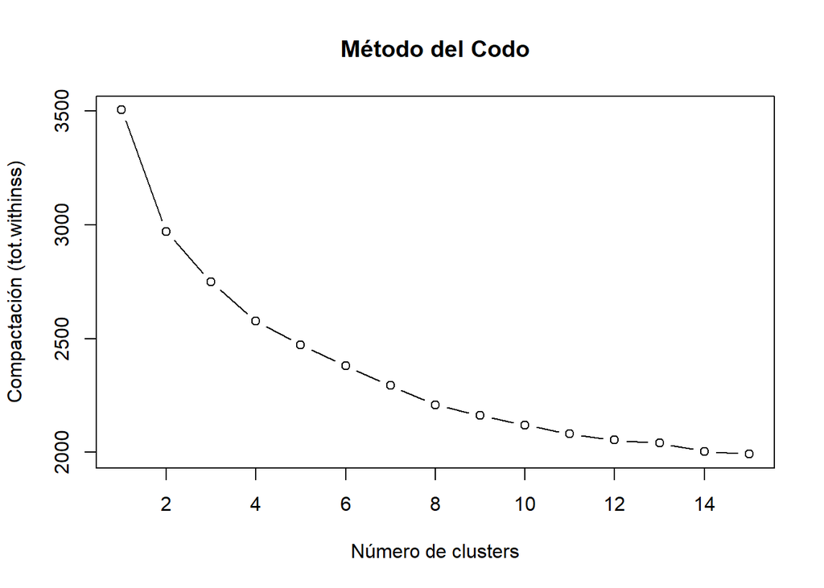

```r
df_num2 <- data_num[, sapply(data_num, is.numeric)]
vector_compactacion <- numeric(15)

for(i in 1:15){
  km_datos3 <- kmeans(df_num2, centers = i, nstart = 20)
  vector_compactacion[i] <- km_datos3$tot.withinss
}

# Grafica
par(mfrow=c(1,1))
plot(1:15, vector_compactacion, type = "b",
     xlab = "Número de clusters",
     ylab = "Compactación (tot.withinss)",
     main = "Método del Codo")
```

```r
km_datos3<-kmeans(df_num,center=2,nstar=20) #segun el metodo del codo
cat('Breast')
```

```
## Breast
```

```r
print(table(km_datos3$cluster, data_num$Cancer_Type=="Breast"))
```

```
##
##     FALSE TRUE
##   1   567  455
##   2   973    5
```

```r
##################
cat('Lung')
```

```
## Lung
```

```r
print(table(km_datos3$cluster, data_num$Cancer_Type=="Lung"))
```

```
##
##     FALSE TRUE
##   1   784  238
##   2   689  289
```

```r
##################
cat('Prostate')
```

```
## Prostate
```

```r
print(table(km_datos3$cluster, data_num$Cancer_Type=="Prostate"))
```

```
##
##     FALSE TRUE
##   1  1022    0
##   2   673  305
```

```r
##################
cat('Skin')
```

```
## Skin
```

```r
print(table(km_datos3$cluster, data_num$Cancer_Type=="Skin"))
```

```
##
##     FALSE TRUE
##   1   890  132
##   2   820  158
```

```r
##################
cat('Colon')
```

```
## Colon
```

```r
print(table(km_datos3$cluster, data_num$Cancer_Type=="Colon"))
```

```
##
##     FALSE TRUE
##   1   825  197
##   2   757  221
```

Vemos que este clustering, para el Cancer de mama, separa un cluster con 455 resultados positivos y otro con 5 resultados. Vemos que hay 5 casos donde el algortimo no distitngue bien. En el cancer de pulmón, separa los casos positivos en dos grupos. En el cancer próstata distingue correctamente de un paciente positivo y negativo pero en los cancer de piel y colon no. Por tanto, es mejor continuar con el dataframe que contiene la variable de tipo de cancer separado

# 6 **APRENDIZAJE SUPERVISADO**

## 6.1 **Modelo predictivo**

En esta sección, entrenaremos dos modelos de Random Forest: uno para clasificar el tipo de cáncer y otro para predecir el nivel de riesgo del paciente.

### 6.1.1 **Random Forest**

```r
# Para Tipo de Cáncer usamos la variable original Cancer_Type
data_tipo <- data_num %>% select(-Overall_Risk_Score, -Risk_Level, -Patient_ID) #quitamos de las variables tambien el Patient_ID ya que no nos interesa asociar un cancer a un paciente
data_tipo$Cancer_Type <- as.factor(data_tipo$Cancer_Type)

# Para Nivel de Riesgo (Clasificación)
data_riesgo <- data_num %>% select(-Cancer_Type, -Overall_Risk_Score, -Patient_ID)
data_riesgo$Risk_Level <- factor(data_riesgo$Risk_Level, levels = c("Low", "Medium", "High"))

# Partición (usamos la misma semilla para que sea reproducible)
set.seed(123)
idx <- createDataPartition(data_tipo$Cancer_Type, p = 0.8, list = FALSE)

train_tipo <- data_tipo[idx, ]
test_tipo  <- data_tipo[-idx, ]

train_riesgo <- data_riesgo[idx, ]
test_riesgo  <- data_riesgo[-idx, ]
```

```r
# Modelo 1: Predicción de Tipo de Cáncer
mod_cancer <- randomForest(Cancer_Type ~ ., data = train_tipo, ntree = 500, importance = TRUE)

# Modelo 2: Predicción de Nivel de Riesgo
mod_riesgo <- randomForest(Risk_Level ~ ., data = train_riesgo, ntree = 500, importance = TRUE)

print(mod_cancer)
```

```
##
## Call:
##  randomForest(formula = Cancer_Type ~ ., data = train_tipo, ntree = 500,      importance = TRUE)
##                Type of random forest: classification
##                      Number of trees: 500
## No. of variables tried at each split: 4
##
##         OOB estimate of  error rate: 22.99%
## Confusion matrix:
##          Breast Colon Lung Prostate Skin class.error
## Breast      309    16   29        2   12  0.16032609
## Colon        24   243   31       25   12  0.27462687
## Lung         15    13  380        5    9  0.09952607
## Prostate      0    22   20      184   18  0.24590164
## Skin         39    18   28       30  117  0.49568966
```

```r
print(mod_riesgo)
```

```
##
## Call:
##  randomForest(formula = Risk_Level ~ ., data = train_riesgo, ntree = 500,      importance = TRUE)
##                Type of random forest: classification
##                      Number of trees: 500
## No. of variables tried at each split: 4
##
##         OOB estimate of  error rate: 15.55%
## Confusion matrix:
##        Low Medium High class.error
## Low    109    158    0  0.59176030
## Medium  20   1235    0  0.01593625
## High     0     71    8  0.89873418
```

En la tabla de confusión de predicción de tipo de cancer, vemos que las variables de cancer tienen un error bajo excepto el cancer de piel, que roza el 50%. Por otro lado, los errores en la predicción del riesgo si son altos. Es cierto que el riesgo Medio es fácil de identificar al tener mucho más volumen datos. Sin embargo, el riesgo Alto, al haber mucho menos datos, no es efectiva la predicción.

```r
# Predicciones
pred_cancer <- predict(mod_cancer, test_tipo)
pred_riesgo <- predict(mod_riesgo, test_riesgo)

# Evaluación del modelo de Tipo de Cáncer
cat("--- Evaluación: Tipo de Cáncer ---\n")
```

```
## --- Evaluación: Tipo de Cáncer ---
```

```r
confusionMatrix(pred_cancer, test_tipo$Cancer_Type)
```

```
## Confusion Matrix and Statistics
##
##           Reference
## Prediction Breast Colon Lung Prostate Skin
##   Breast       78     4    2        0    4
##   Colon         5    57    4        1   11
##   Lung          6    11   93        6   11
##   Prostate      1     8    4       50    7
##   Skin          2     3    2        4   25
##
## Overall Statistics
##
##                Accuracy : 0.7594
##                  95% CI : (0.7144, 0.8005)
##     No Information Rate : 0.2632
##     P-Value [Acc > NIR] : < 2.2e-16
##
##                   Kappa : 0.6934
##
##  Mcnemar's Test P-Value : 0.006358
##
## Statistics by Class:
##
##                      Class: Breast Class: Colon Class: Lung Class: Prostate
## Sensitivity                 0.8478       0.6867      0.8857          0.8197
## Specificity                 0.9674       0.9335      0.8844          0.9408
## Pos Pred Value              0.8864       0.7308      0.7323          0.7143
## Neg Pred Value              0.9550       0.9190      0.9559          0.9666
## Prevalence                  0.2306       0.2080      0.2632          0.1529
## Detection Rate              0.1955       0.1429      0.2331          0.1253
## Detection Prevalence        0.2206       0.1955      0.3183          0.1754
## Balanced Accuracy           0.9076       0.8101      0.8850          0.8803
##                      Class: Skin
## Sensitivity              0.43103
## Specificity              0.96774
## Pos Pred Value           0.69444
## Neg Pred Value           0.90909
## Prevalence               0.14536
## Detection Rate           0.06266
## Detection Prevalence     0.09023
## Balanced Accuracy        0.69939
```

```r
# Evaluación del modelo de Nivel de Riesgo
cat("\n--- Evaluación: Nivel de Riesgo ---\n")
```

```
##
## --- Evaluación: Nivel de Riesgo ---
```

```r
confusionMatrix(pred_riesgo, test_riesgo$Risk_Level)
```

```
## Confusion Matrix and Statistics
##
##           Reference
## Prediction Low Medium High
##     Low     19      4    0
##     Medium  38    315   23
##     High     0      0    0
##
## Overall Statistics
##
##                Accuracy : 0.8371
##                  95% CI : (0.7971, 0.872)
##     No Information Rate : 0.7995
##     P-Value [Acc > NIR] : 0.03253
##
##                   Kappa : 0.3165
##
##  Mcnemar's Test P-Value : NA
##
## Statistics by Class:
##
##                      Class: Low Class: Medium Class: High
## Sensitivity             0.33333        0.9875     0.00000
## Specificity             0.98830        0.2375     1.00000
## Pos Pred Value          0.82609        0.8378         NaN
## Neg Pred Value          0.89894        0.8261     0.94236
## Prevalence              0.14286        0.7995     0.05764
## Detection Rate          0.04762        0.7895     0.00000
## Detection Prevalence    0.05764        0.9424     0.00000
## Balanced Accuracy       0.66082        0.6125     0.50000
```

En la predicción del riesgo, encontramos una precisión del 83.71%. Sin embargo, no indica la eficiencia del algoritmo, ya que, debido al alto número de riesgo Medio, aumenta la preicisón. Sin embargo, la sensibilidad del riesgo ‘Alto’ es 0 y su precisión balanceada es de 0,5. A continuación, probaremos el algortimo seleccionando las variables más determinantes

#### 6.1.1.1 Variables determinantes

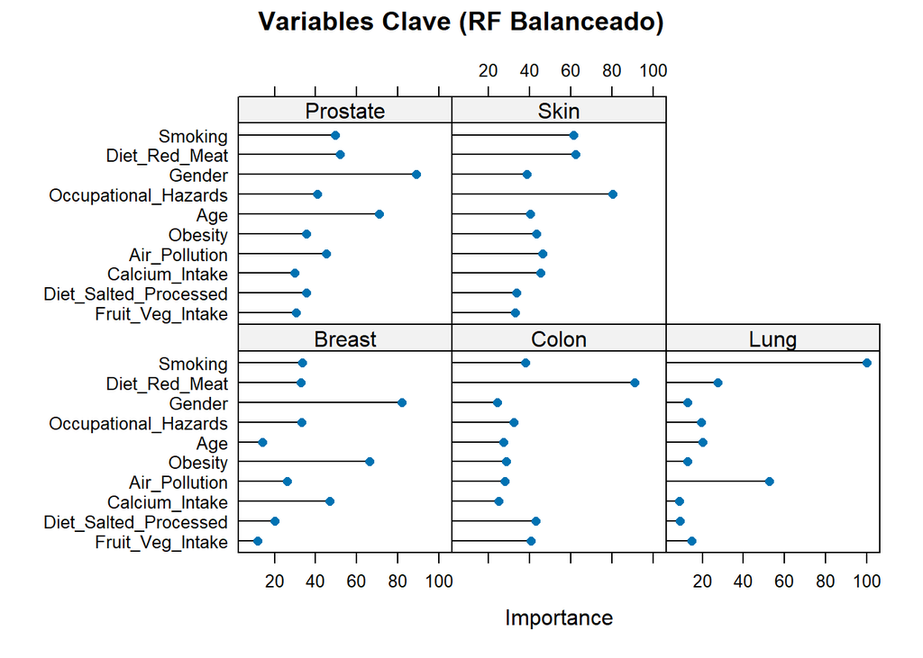

```r
# Configuración del entrenamiento con SMOTE
ctrl_rf <- trainControl(
  method = "cv",
  number = 5,
  sampling = "smote" # Balanceo automático
)

set.seed(123)
# Entrenamos el modelo balanceado
mod_rf_bal_cancer <- train(
  Cancer_Type ~ .,
  data = train_tipo,
  method = "rf",
  trControl = ctrl_rf,
  importance = TRUE,
  ntree = 250 # Reducimos un poco para agilizar el proceso
)

imp_rf_cancer <- varImp(mod_rf_bal_cancer)
plot(imp_rf_cancer, top = 10, main = "Variables Clave (RF Balanceado)")
```

```r
# Evaluación
pred_rf_bal_cancer <- predict(mod_rf_bal_cancer, test_tipo)
confusionMatrix(pred_rf_bal_cancer, test_tipo$Cancer_Type)
```

```
## Confusion Matrix and Statistics
##
##           Reference
## Prediction Breast Colon Lung Prostate Skin
##   Breast       78     6    2        0    4
##   Colon         6    52    4        2    9
##   Lung          5    10   94        8    7
##   Prostate      1     9    2       46    7
##   Skin          2     6    3        5   31
##
## Overall Statistics
##
##                Accuracy : 0.7544
##                  95% CI : (0.7091, 0.7959)
##     No Information Rate : 0.2632
##     P-Value [Acc > NIR] : < 2e-16
##
##                   Kappa : 0.6876
##
##  Mcnemar's Test P-Value : 0.09648
##
## Statistics by Class:
##
##                      Class: Breast Class: Colon Class: Lung Class: Prostate
## Sensitivity                 0.8478       0.6265      0.8952          0.7541
## Specificity                 0.9609       0.9335      0.8980          0.9438
## Pos Pred Value              0.8667       0.7123      0.7581          0.7077
## Neg Pred Value              0.9547       0.9049      0.9600          0.9551
## Prevalence                  0.2306       0.2080      0.2632          0.1529
## Detection Rate              0.1955       0.1303      0.2356          0.1153
## Detection Prevalence        0.2256       0.1830      0.3108          0.1629
## Balanced Accuracy           0.9044       0.7800      0.8966          0.8489
##                      Class: Skin
## Sensitivity              0.53448
## Specificity              0.95308
## Pos Pred Value           0.65957
## Neg Pred Value           0.92330
## Prevalence               0.14536
## Detection Rate           0.07769
## Detection Prevalence     0.11779
## Balanced Accuracy        0.74378
```

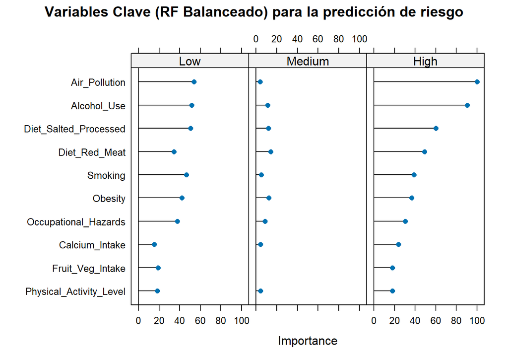

```r
ctrl_rf <- trainControl(
  method = "cv",
  number = 5,
  sampling = "smote" # Balanceo automático
)

set.seed(123)

mod_rf_bal_riesgo <- train(
  Risk_Level ~ .,
  data = train_riesgo,
  method = "rf",
  trControl = ctrl_rf,
  importance = TRUE,
  ntree = 250 # Reducimos un poco para agilizar el proceso
)

imp_rf_riesgo <- varImp(mod_rf_bal_riesgo)
plot(imp_rf_riesgo, top = 10, main = "Variables Clave (RF Balanceado) para la predicción de riesgo")
```

En este caso es bastante sorprendente ya en el resigo Medio, las variables tiene practicamente todas el mismo peso y con una importancia bastante baja. Esto se debe a la gran cantidad de datos de Riesgo Medio que encontramos, que hace que es desbalanceado. En el riesgo Bajo no encontramos ningún resultado concluyente y sin embargo, en el riesgo Alto, vemos que destacan princiaplmente tres variables por encima del 50%. Estos son Air_pullion, Alcohol_Use y Diet_Salted_Processed-

```r
# Evaluación
pred_rf_bal_riesgo <- predict(mod_rf_bal_riesgo, test_riesgo)
confusionMatrix(pred_rf_bal_riesgo, test_riesgo$Risk_Level)
```

```
## Confusion Matrix and Statistics
##
##           Reference
## Prediction Low Medium High
##     Low     32     20    0
##     Medium  25    290   14
##     High     0      9    9
##
## Overall Statistics
##
##                Accuracy : 0.8296
##                  95% CI : (0.789, 0.8652)
##     No Information Rate : 0.7995
##     P-Value [Acc > NIR] : 0.07316
##
##                   Kappa : 0.4667
##
##  Mcnemar's Test P-Value : NA
##
## Statistics by Class:
##
##                      Class: Low Class: Medium Class: High
## Sensitivity              0.5614        0.9091     0.39130
## Specificity              0.9415        0.5125     0.97606
## Pos Pred Value           0.6154        0.8815     0.50000
## Neg Pred Value           0.9280        0.5857     0.96325
## Prevalence               0.1429        0.7995     0.05764
## Detection Rate           0.0802        0.7268     0.02256
## Detection Prevalence     0.1303        0.8246     0.04511
## Balanced Accuracy        0.7515        0.7108     0.68368
```

En esta predicción, encontramos resultados mucho más positivos. Vemos una precisión del 82.96%, la precisión balanceada sube en las clases ‘Baja’ y ‘Alta’ y la sensibilidad de la clase ‘Alta’ ha subido de 0 a 39.13%

### 6.1.2 **KNN**

```r
# Excluimos Cancer_Type y cualquier columna que no sea número. Las que quitamos serán Risk_Level (que podemos seguir obtiendo resultado mediante Overall_Risk_Level)y Patient_ID, que en este momento no nos interesa
train_x <- train_tipo %>%
  select(where(is.numeric)) %>%
  select(-starts_with("Cancer_Type_"))

test_x <- test_tipo %>%
  select(where(is.numeric)) %>%
  select(-starts_with("Cancer_Type_"))

train_y <- as.factor(train_tipo$Cancer_Type)
```

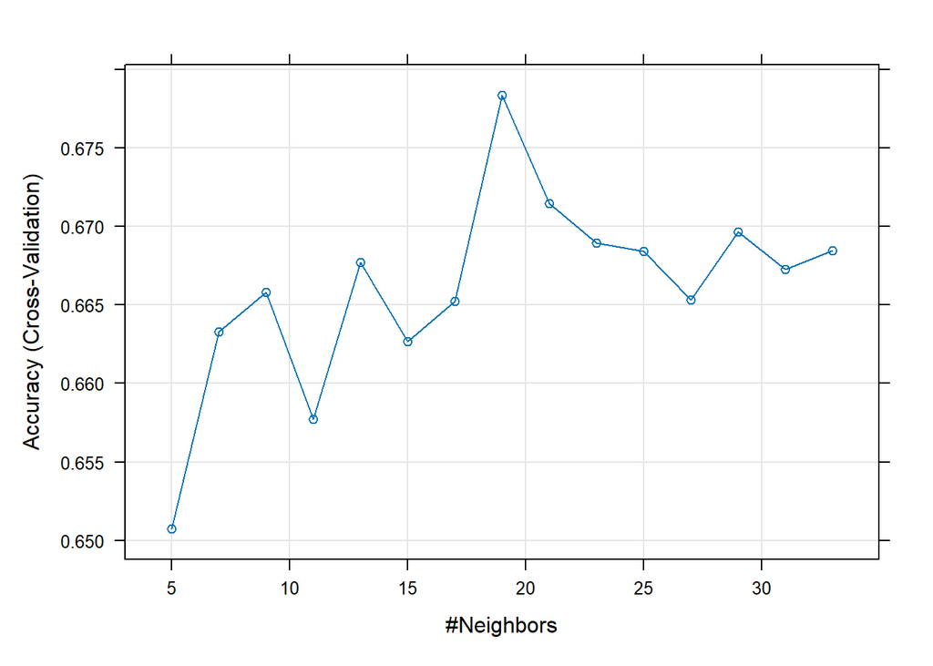

```r
train_knn_final <- train_x
train_knn_final$Cancer_Type <- train_y

# Búsqueda automática de la mejor K
set.seed(123)
modelo_knn_auto <- train(Cancer_Type ~ .,
                         data = train_knn_final,
                         method = "knn",
                         tuneLength = 15,
                         trControl = trainControl(method = "cv"))

plot(modelo_knn_auto)
```

En esta gráfica podemos observar como aumenta la precisión a medida que el caso es comparado con un k mayor de vecinos. Como vemos que la gráfica tiene un pico alrededor de 18-19 vecinos. Consideraremos esa la k óptima. Probaremos con 18

```r
pred_knn_manual <- knn(train = train_x,
                       test = test_x,
                       cl = train_y,
                       k = 18)

# Evaluación
cat("\n--- Evaluación KNN: Tipo de cancer de manera manual ---\n")
```

```
##
## --- Evaluación KNN: Tipo de cancer de manera manual ---
```

```r
confusionMatrix(pred_knn_manual, test_tipo$Cancer_Type)
```

```
## Confusion Matrix and Statistics
##
##           Reference
## Prediction Breast Colon Lung Prostate Skin
##   Breast       83    13   11        0   14
##   Colon         4    45    6        4   12
##   Lung          3     9   86       13   12
##   Prostate      1    13    1       40    4
##   Skin          1     3    1        4   16
##
## Overall Statistics
##
##                Accuracy : 0.6767
##                  95% CI : (0.6284, 0.7224)
##     No Information Rate : 0.2632
##     P-Value [Acc > NIR] : < 2.2e-16
##
##                   Kappa : 0.5856
##
##  Mcnemar's Test P-Value : 1.16e-07
##
## Statistics by Class:
##
##                      Class: Breast Class: Colon Class: Lung Class: Prostate
## Sensitivity                 0.9022       0.5422      0.8190          0.6557
## Specificity                 0.8762       0.9177      0.8741          0.9438
## Pos Pred Value              0.6860       0.6338      0.6992          0.6780
## Neg Pred Value              0.9676       0.8841      0.9312          0.9382
## Prevalence                  0.2306       0.2080      0.2632          0.1529
## Detection Rate              0.2080       0.1128      0.2155          0.1003
## Detection Prevalence        0.3033       0.1779      0.3083          0.1479
## Balanced Accuracy           0.8892       0.7299      0.8466          0.7998
##                      Class: Skin
## Sensitivity              0.27586
## Specificity              0.97361
## Pos Pred Value           0.64000
## Neg Pred Value           0.88770
## Prevalence               0.14536
## Detection Rate           0.04010
## Detection Prevalence     0.06266
## Balanced Accuracy        0.62473
```

Vemos una precisión del 67.67% pero sigue sin ser mejor que la de RandomForest. Veremos ahora la evaluación del riesgo

```r
# Preparar datos para Riesgo
train_riesgo_x <- train_riesgo %>% select(where(is.numeric))
test_riesgo_x  <- test_riesgo %>% select(where(is.numeric))
train_riesgo_y <- train_riesgo$Risk_Level

# Ejecutar KNN para Riesgo (k=12 por ejemplo)
pred_knn_riesgo <- knn(train = train_riesgo_x,
                       test = test_riesgo_x,
                       cl = train_riesgo_y,
                       k = 12)

# Evaluación
cat("\n--- Evaluación KNN: Nivel de Riesgo ---\n")
```

```
##
## --- Evaluación KNN: Nivel de Riesgo ---
```

```r
confusionMatrix(pred_knn_riesgo, test_riesgo$Risk_Level)
```

```
## Confusion Matrix and Statistics
##
##           Reference
## Prediction Low Medium High
##     Low     18     10    0
##     Medium  39    309   23
##     High     0      0    0
##
## Overall Statistics
##
##                Accuracy : 0.8195
##                  95% CI : (0.7782, 0.856)
##     No Information Rate : 0.7995
##     P-Value [Acc > NIR] : 0.1745
##
##                   Kappa : 0.2682
##
##  Mcnemar's Test P-Value : NA
##
## Statistics by Class:
##
##                      Class: Low Class: Medium Class: High
## Sensitivity             0.31579        0.9687     0.00000
## Specificity             0.97076        0.2250     1.00000
## Pos Pred Value          0.64286        0.8329         NaN
## Neg Pred Value          0.89488        0.6429     0.94236
## Prevalence              0.14286        0.7995     0.05764
## Detection Rate          0.04511        0.7744     0.00000
## Detection Prevalence    0.07018        0.9298     0.00000
## Balanced Accuracy       0.64327        0.5968     0.50000
```

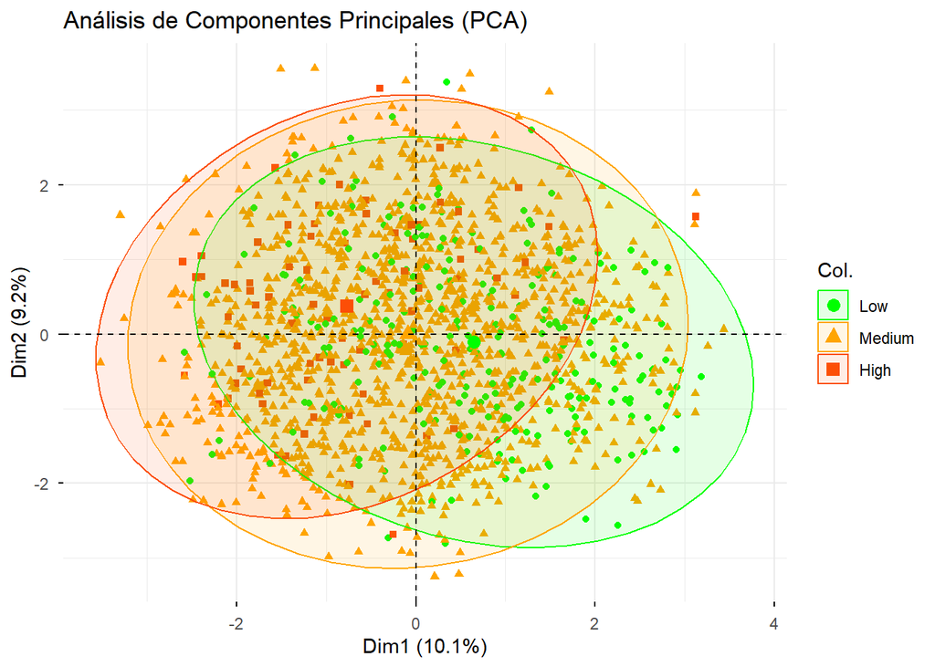

```r
datos_solo_numeros <- train_riesgo %>%
  select(where(is.numeric))

res_pca <- prcomp(datos_solo_numeros, scale. = TRUE)

fviz_pca_ind(res_pca,
             geom.ind = "point",
             col.ind = train_riesgo$Risk_Level,
             palette = c("green", "orange", "#FC4E07"),
             addEllipses = TRUE,
             title = "Análisis de Componentes Principales (PCA)")
```

### 6.1.3 **Árbol de decisión**

Predicción de tipos de cancer

```r
set.seed(123)

# Dataset para tipo de cáncer
data_tipo <- data_num %>%
  select(-Overall_Risk_Score, -Risk_Level, -Patient_ID)
data_tipo$Cancer_Type <- as.factor(data$Cancer_Type)

# División train/test
idx <- createDataPartition(data_tipo$Cancer_Type, p = 0.8
                           , list = FALSE)
train_tipo <- data_tipo[idx, ]
test_tipo  <- data_tipo[-idx, ]

# Entrenamiento con control para evitar sobrecarga de CPU
ctrl <- trainControl(method = "cv", number = 10, sampling = "smote")

modelo_arbol <- train(
  Cancer_Type ~ .,
  data = train_tipo,
  method = "rpart",
  trControl = ctrl,
  tuneLength = 8
)

# Resultados
print(modelo_arbol)
```

```
## CART
##
## 1601 samples
##   17 predictor
##    5 classes: 'Breast', 'Colon', 'Lung', 'Prostate', 'Skin'
##
## No pre-processing
## Resampling: Cross-Validated (10 fold)
## Summary of sample sizes: 1441, 1442, 1441, 1440, 1440, 1443, ...
## Addtional sampling using SMOTE
##
## Resampling results across tuning parameters:
##
##   cp          Accuracy   Kappa
##   0.01102629  0.6576075  0.5636544
##   0.01357082  0.6451424  0.5478074
##   0.01696353  0.6407436  0.5424039
##   0.02120441  0.6313803  0.5304123
##   0.03901612  0.6001828  0.4861572
##   0.06276506  0.5602704  0.4378944
##   0.17217981  0.5602704  0.4378944
##   0.23070399  0.2298554  0.0000000
##
## Accuracy was used to select the optimal model using the largest value.
## The final value used for the model was cp = 0.01102629.
```

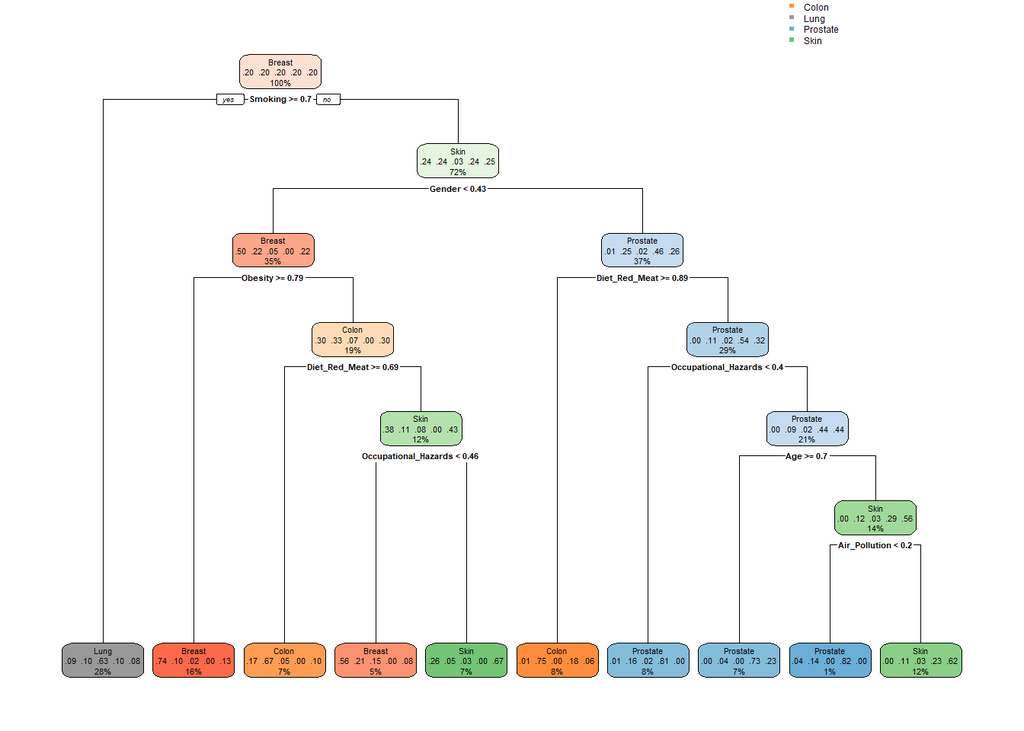

```r
rpart.plot(modelo_arbol$finalModel)
```

```r
# Evaluación
pred_arbol <- predict(modelo_arbol, test_tipo)
confusionMatrix(pred_arbol, test_tipo$Cancer_Type)
```

```
## Confusion Matrix and Statistics
##
##           Reference
## Prediction Breast Colon Lung Prostate Skin
##   Breast       66     5    5        0    5
##   Colon         6    49    6        3   11
##   Lung         13    13   89       13   10
##   Prostate      0     8    3       39    7
##   Skin          7     8    2        6   25
##
## Overall Statistics
##
##                Accuracy : 0.6717
##                  95% CI : (0.6232, 0.7176)
##     No Information Rate : 0.2632
##     P-Value [Acc > NIR] : < 2.2e-16
##
##                   Kappa : 0.5811
##
##  Mcnemar's Test P-Value : NA
##
## Statistics by Class:
##
##                      Class: Breast Class: Colon Class: Lung Class: Prostate
## Sensitivity                 0.7174       0.5904      0.8476         0.63934
## Specificity                 0.9511       0.9177      0.8333         0.94675
## Pos Pred Value              0.8148       0.6533      0.6449         0.68421
## Neg Pred Value              0.9182       0.8951      0.9387         0.93567
## Prevalence                  0.2306       0.2080      0.2632         0.15288
## Detection Rate              0.1654       0.1228      0.2231         0.09774
## Detection Prevalence        0.2030       0.1880      0.3459         0.14286
## Balanced Accuracy           0.8343       0.7540      0.8405         0.79304
##                      Class: Skin
## Sensitivity              0.43103
## Specificity              0.93255
## Pos Pred Value           0.52083
## Neg Pred Value           0.90598
## Prevalence               0.14536
## Detection Rate           0.06266
## Detection Prevalence     0.12030
## Balanced Accuracy        0.68179
```

```r
resultado_evaluacion <- confusionMatrix(pred_arbol, test_tipo$Cancer_Type)
cat("El Accuracy del modelo de Árbol de Decisión es:", resultado_evaluacion$overall['Accuracy'], "\n")
```

```
## El Accuracy del modelo de Árbol de Decisión es: 0.6716792
```

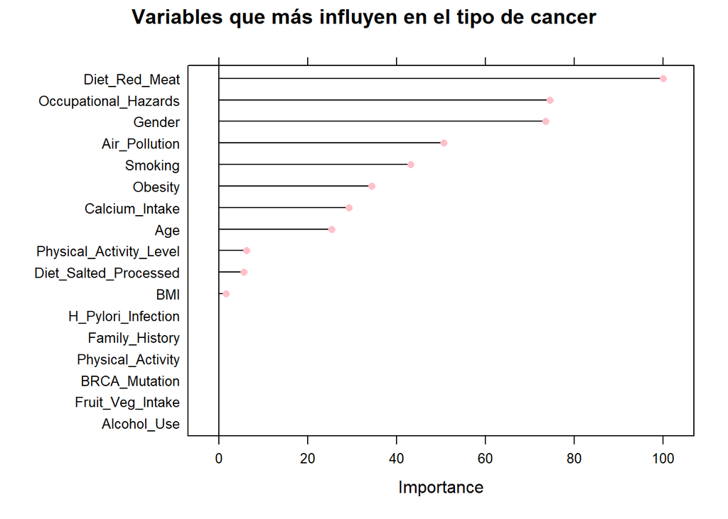

```r
importancia_cancer <- varImp(modelo_arbol)

tabla_importancia <- importancia_cancer$importance

plot(importancia_cancer,
     main = "Variables que más influyen en el tipo de cancer",
     col = "pink")
```

```r
eliminadas <- tabla_importancia[tabla_importancia$Overall < 20, , drop=FALSE]

print("Variables con importancia menor a 20")
```

```
## [1] "Variables con importancia menor a 20"
```

```r
print(eliminadas)
```

```
##                          Overall
## BMI                     1.568968
## Diet_Salted_Processed   5.601101
## Physical_Activity_Level 6.216745
## Alcohol_Use             0.000000
## Family_History          0.000000
## Fruit_Veg_Intake        0.000000
## Physical_Activity       0.000000
## BRCA_Mutation           0.000000
## H_Pylori_Infection      0.000000
```

En este gráfico vemos las variables que más influyen en la decisión del tipo de cancer. Podríamos probar realizar el algoritmo solo con las que suponen un 20% ya que, vemos que hay variables que no tienen efecto sobre la decisión

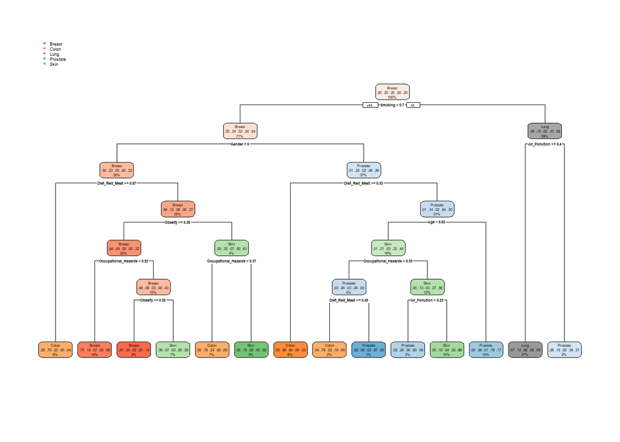

```r
set.seed(123)

# Dataset para tipo de cáncer
data_tipo2 <- data_num %>%
  select(-Overall_Risk_Score, -Risk_Level, -Patient_ID) %>%
  select(-all_of(rownames(eliminadas)))

data_tipo2$Cancer_Type <- as.factor(data$Cancer_Type)

# División train/test
idx <- createDataPartition(data_tipo2$Cancer_Type, p = 0.8
                           , list = FALSE)
train_tipo2 <- data_tipo2[idx, ]
test_tipo2  <- data_tipo2[-idx, ]

# Entrenamiento con control para evitar sobrecarga de CPU
ctrl2 <- trainControl(method = "cv", number = 10, sampling = "smote")

modelo_arbol_var <- train(
  Cancer_Type ~ .,
  data = train_tipo2,
  method = "rpart",
  trControl = ctrl2,
  tuneLength = 10
)

rpart.plot(modelo_arbol_var$finalModel)
```

```r
pred_arbol_var <- predict(modelo_arbol_var, test_tipo2)
confusionMatrix(pred_arbol_var, test_tipo2$Cancer_Type)
```

```
## Confusion Matrix and Statistics
##
##           Reference
## Prediction Breast Colon Lung Prostate Skin
##   Breast       56     7    5        0    3
##   Colon         7    44    7        4    7
##   Lung         11    11   89       12   10
##   Prostate      3    10    3       42   13
##   Skin         15    11    1        3   25
##
## Overall Statistics
##
##                Accuracy : 0.6416
##                  95% CI : (0.5924, 0.6887)
##     No Information Rate : 0.2632
##     P-Value [Acc > NIR] : < 2.2e-16
##
##                   Kappa : 0.5452
##
##  Mcnemar's Test P-Value : 6.602e-05
##
## Statistics by Class:
##
##                      Class: Breast Class: Colon Class: Lung Class: Prostate
## Sensitivity                 0.6087       0.5301      0.8476          0.6885
## Specificity                 0.9511       0.9209      0.8503          0.9142
## Pos Pred Value              0.7887       0.6377      0.6692          0.5915
## Neg Pred Value              0.8902       0.8818      0.9398          0.9421
## Prevalence                  0.2306       0.2080      0.2632          0.1529
## Detection Rate              0.1404       0.1103      0.2231          0.1053
## Detection Prevalence        0.1779       0.1729      0.3333          0.1779
## Balanced Accuracy           0.7799       0.7255      0.8490          0.8014
##                      Class: Skin
## Sensitivity              0.43103
## Specificity              0.91202
## Pos Pred Value           0.45455
## Neg Pred Value           0.90407
## Prevalence               0.14536
## Detection Rate           0.06266
## Detection Prevalence     0.13784
## Balanced Accuracy        0.67153
```

```r
pred_arbol_var <- predict(modelo_arbol_var, test_tipo2)

resultado_evaluacion2 <- confusionMatrix(pred_arbol_var, test_tipo2$Cancer_Type)
cat("El Accuracy del modelo de Árbol de Decisión con variables truncadas es:", resultado_evaluacion2$overall['Accuracy'], "\n")
```

```
## El Accuracy del modelo de Árbol de Decisión con variables truncadas es: 0.641604
```

```r
print(resultado_evaluacion2)
```

```
## Confusion Matrix and Statistics
##
##           Reference
## Prediction Breast Colon Lung Prostate Skin
##   Breast       56     7    5        0    3
##   Colon         7    44    7        4    7
##   Lung         11    11   89       12   10
##   Prostate      3    10    3       42   13
##   Skin         15    11    1        3   25
##
## Overall Statistics
##
##                Accuracy : 0.6416
##                  95% CI : (0.5924, 0.6887)
##     No Information Rate : 0.2632
##     P-Value [Acc > NIR] : < 2.2e-16
##
##                   Kappa : 0.5452
##
##  Mcnemar's Test P-Value : 6.602e-05
##
## Statistics by Class:
##
##                      Class: Breast Class: Colon Class: Lung Class: Prostate
## Sensitivity                 0.6087       0.5301      0.8476          0.6885
## Specificity                 0.9511       0.9209      0.8503          0.9142
## Pos Pred Value              0.7887       0.6377      0.6692          0.5915
## Neg Pred Value              0.8902       0.8818      0.9398          0.9421
## Prevalence                  0.2306       0.2080      0.2632          0.1529
## Detection Rate              0.1404       0.1103      0.2231          0.1053
## Detection Prevalence        0.1779       0.1729      0.3333          0.1779
## Balanced Accuracy           0.7799       0.7255      0.8490          0.8014
##                      Class: Skin
## Sensitivity              0.43103
## Specificity              0.91202
## Pos Pred Value           0.45455
## Neg Pred Value           0.90407
## Prevalence               0.14536
## Detection Rate           0.06266
## Detection Prevalence     0.13784
## Balanced Accuracy        0.67153
```

Árbol de decision para el riesgo

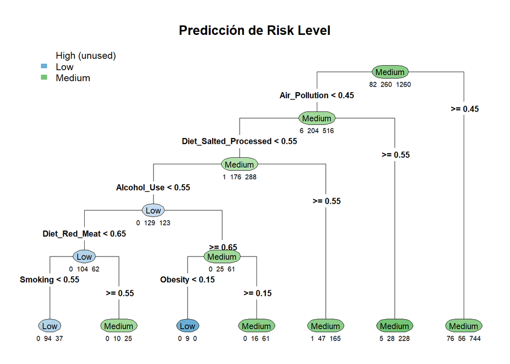

```r
data_reg <- data_num %>%
  select(-Patient_ID, -Cancer_Type, -Overall_Risk_Score)

set.seed(123)
idx_reg <- createDataPartition(data_reg$Risk_Level, p = 0.8, list = FALSE)
train_reg <- data_reg[idx_reg, ]
test_reg  <- data_reg[-idx_reg, ]

modelo_risk <- train(
  Risk_Level ~ .,
  data = train_reg,
  method = "rpart",
  trControl = trainControl(method = "cv", number = 10)
)
rpart.plot(modelo_risk$finalModel,
           main = "Predicción de Risk Level",
           type = 4,
           extra = 1,
           under = TRUE,
           cex = 0.7)
```

```r
pred_riesgo <- predict(modelo_risk, test_reg)
```

```r
pred_riesgo <- predict(modelo_risk, test_reg)
niveles <- c("Low", "Medium", "High")

pred_riesgo_factor <- factor(pred_riesgo, levels = niveles)
test_reg_real      <- factor(test_reg$Risk_Level, levels = niveles)

resultado_evaluacion2 <- confusionMatrix(pred_riesgo_factor, test_reg_real)

cat("El Accuracy del modelo de Árbol de Decisión con variables truncadas es:",
    resultado_evaluacion2$overall['Accuracy'], "\n")
```

```
## El Accuracy del modelo de Árbol de Decisión con variables truncadas es: 0.8190955
```

```r
print(resultado_evaluacion2)
```

```
## Confusion Matrix and Statistics
##
##           Reference
## Prediction Low Medium High
##     Low     23     11    0
##     Medium  41    303   20
##     High     0      0    0
##
## Overall Statistics
##
##                Accuracy : 0.8191
##                  95% CI : (0.7777, 0.8557)
##     No Information Rate : 0.7889
##     P-Value [Acc > NIR] : 0.07699
##
##                   Kappa : 0.3166
##
##  Mcnemar's Test P-Value : NA
##
## Statistics by Class:
##
##                      Class: Low Class: Medium Class: High
## Sensitivity             0.35938        0.9650     0.00000
## Specificity             0.96707        0.2738     1.00000
## Pos Pred Value          0.67647        0.8324         NaN
## Neg Pred Value          0.88736        0.6765     0.94975
## Prevalence              0.16080        0.7889     0.05025
## Detection Rate          0.05779        0.7613     0.00000
## Detection Prevalence    0.08543        0.9146     0.00000
## Balanced Accuracy       0.66322        0.6194     0.50000
```

## 6.2 CONCLUSIÓN

Para estudios futuros y tener una mejor precisión, sería recomendable aumentar el número de casos con riesgo alto para que el dataset sea más balanceado. Además, sería tmabién muy util tomar datos más exactos como el componente genético del árbol genealógico, posibles trastornos mentales, el tipo de ejercicio que conlleva la actividad física… Sería mucho más claro para el médico entender la toma de decisión del algortimo y evitar así la caja negra.

**BIBLIOGRAFÍA**

Origen de los datos: Dataset público “cancer-risk-factors.csv”`. Repositorio de factores de riesgo y registros clínicos oncológicos en Kaggle https://www.kaggle.com/datasets/tarekmasryo/cancer-risk-factors-dataset